# Data Wrangling & Visualization

Skills Quiz

Andrew Seaman

2025-Jan-23

# Questions

## Summary

### Introduction

The quiz involves analyzing multiple datasets (KidsFeet, airquality, Riders, and mtcars) using tidyverse and mosaic functions in R. It focuses on key data wrangling and visualization skills, including:

- Summarizing categorical data (e.g., gender distribution, birth month counts).
- Computing descriptive statistics (e.g., mean, median, quartiles for numerical data).
- Filtering and grouping data (e.g., monthly temperature trends, weight of vehicles).
- Comparing values (e.g., largest month-to-month temperature difference, heaviest cars).
- Using visualization techniques (e.g., histograms, boxplots, stripcharts).
- Applying functions and pipelines to streamline computations.

The quiz ensures proficiency in data exploration, summarization, and visualization using R, essential for effective data analysis.

### Questions (5)

##### Q2

Analyzes the KidsFeet dataset to determine gender distribution, foot dominance, birth month distribution, and statistical summaries of foot length.

##### Q3

Examines the airquality dataset to compute monthly temperature averages, identify the coolest month, calculate differences between July and August, and determine the largest month-to-month temperature change.

##### Q4

Reformats the airquality dataset to display mean temperatures for each month with formatted month labels.

##### Q5

Aggregates the Riders dataset to compute the total number of riders observed per day of the week, ensuring correct ordering of weekdays.

##### Q6

Investigates the mtcars dataset, counting variables and records, analyzing cylinder distribution, fuel efficiency, and quarter-mile times, and determining the heaviest 6-cylinder vehicles.

## Q2

#### 2.1

How many boys and girls are there in this dataset?

```r
# a. How many boys and girls are there in this dataset?
table_var <- function(df, var) {
  df %>%
    pull({{ var }}) %>%  # Convert to a vector
    table() %>%
    pander()
}

table_var(KidsFeet, sex)
```

| B | G |
| --- | --- |
| 20 | 19 |

#### 2.2

Which foot is more commonly the bigger foot (happens the most in this dataset)?

```r
# b. Which foot is more commonly the bigger foot (happens the most in this dataset?
table_var(KidsFeet, biggerfoot)
```

| L | R |
| --- | --- |
| 22 | 17 |

#### 2.3

Which birth month is most common among these sampled children?

```r
# c. Which birth month is most common among these sampled children?
KidsFeet %>%
  mutate(
    `Birth Month` = factor(
      month.abb[birthmonth],
      levels = c("Jan", "Feb", "Mar", "Apr", "May", "Jun", "Jul", "Aug", "Sep", "Oct", "Nov", "Dec")
    )  # Correctly apply factor() only to `Birth Month`
  ) %>%
  count(`Birth Month`) %>%
  pander()
```

| Birth Month | n |
| --- | --- |
| Jan | 2 |
| Feb | 3 |
| Mar | 8 |
| Apr | 3 |
| May | 2 |
| Jun | 4 |
| Jul | 3 |
| Aug | 2 |
| Sep | 5 |
| Oct | 2 |
| Nov | 2 |
| Dec | 3 |

#### 2.4

Note that the table( ) function can also be used with two variables at once. This can help answer questions like, “are girls or boys more likely to be left handed?”

```r
# d. "Are girls or boys more likely to be left handed?"
table_vars <- function(df, var1, var2) {
  df %>%
    select({{ var1 }}, {{ var2 }}) %>%
    as.data.frame() %>%  # Ensure it's a standard dataframe
    table() %>%
    pander()
}

table_vars(KidsFeet, domhand, sex)
```

|  | B | G |
| --- | --- | --- |
| **L** | 5 | 3 |
| **R** | 15 | 16 |

#### 2.5

The **group_by( )** and **summarise( )** functions are very useful for computing “our favorite statistics” of quantitative variables. This is demonstrated in your Math 325 Notebook >> Describing Data >> Numerical Summaries >> Five-number Summary as well as in your R Commands page at the bottom under “group_by and summarise”.

Be sure library(tidyverse) is loaded, then use group_by( ) and summarise( ) to obtain the values needed to fill in the following table.

```r
# e. Summaries of children's foot lengths according to their gender.
KidsFeet %>%
  group_by(sex) %>%
  summarise(
    min = min(length, na.rm = TRUE),
    Q1 = quantile(length, 0.25, na.rm = TRUE),
    median = median(length, na.rm = TRUE),
    Q3 = quantile(length, 0.75, na.rm = TRUE),
    max = max(length, na.rm = TRUE),
    mean = mean(length, na.rm = TRUE),
    sd = sd(length, na.rm = TRUE),
    n = n(),
    missing = sum(is.na(length))
  ) %>%
  pander()
```

| sex | min | Q1 | median | Q3 | max | mean | sd | n | missing |
| --- | --- | --- | --- | --- | --- | --- | --- | --- | --- |
| B | 22.9 | 24.35 | 24.95 | 25.8 | 27.5 | 25.1 | 1.217 | 20 | 0 |
| G | 21.6 | 23.65 | 24.2 | 25.1 | 26.7 | 24.32 | 1.33 | 19 | 0 |

#### 2.6

For this particular sample of data, which gender has the longest feet on average?

```r
# f. For this particular sample of data, which gender has the longest feet on average?
answer <- KidsFeet %>%
  group_by(sex) %>%
  summarise(mean_length = mean(length, na.rm = TRUE)) %>%
  filter(mean_length == max(mean_length)) %>%  # Keep only the max mean
  mutate(sex = if_else(sex == "B", "Boys", "Girls")) %>%
  pull(sex)  # Extract value

cat("Longest feet on average:", answer, "\n")
```

```
## Longest feet on average: Boys
```

#### 2.7

Which gender shows the most consistency in length of feet among children in this sample?

```r
# g. Which gender shows the most consistency in length of feet among children in this sample?
answer <- KidsFeet %>%
  group_by(sex) %>%
  summarise(sd_length = sd(length, na.rm = TRUE)) %>%
  filter(sd_length == min(sd_length)) %>%  # Keep only the max mean
  mutate(sex = if_else(sex == "B", "Boys", "Girls")) %>%
  pull(sex)  # Extract value

cat("Most consistent foot length:", answer, "\n")
```

```
## Most consistent foot length: Boys
```

## Q3

#### Introduction

It is often of interest to obtain the mean (or another statistic) of data for several groups. The following questions will help you practice doing this in R.

Your R Code / Numerical Summaries page of your Math 325 Notebook should help you answer the questions on this page.

In your R Console, type the commands:

> ?airquality  
> View(airquality)  
> library(mosaic)

#### 3.1

Then, run an appropriate command to obtain the mean daily temperature at LaGuardia Airport for each month, separately. What was the average (mean) temperature for each month?

```r
# a. What was the average (mean) temperature for each month?
airquality %>%
  group_by(Month) %>%
  summarise(
    `Month Number` = first(Month),
    `Month Name` = first(month.name[Month]),
    `Mean Temp` = mean(Temp, na.rm = TRUE)
  ) %>%
  ungroup() %>%
  distinct(`Month Name`, .keep_all = TRUE) %>%
  arrange(`Month Number`) %>%
  select("Month Number", "Month Name", "Mean Temp") %>%
  pander()
```

| Month Number | Month Name | Mean Temp |
| --- | --- | --- |
| 5 | May | 65.55 |
| 6 | June | 79.1 |
| 7 | July | 83.9 |
| 8 | August | 83.97 |
| 9 | September | 76.9 |

#### 3.2

Which month experiences the coolest average temperature?

```r
# b. Which month experiences the coolest average temperature?
coolest_month <- airquality %>%
  group_by(Month) %>%
  summarise(
    "Month Number" = first(Month),
    "Month Name" = first(month.name[Month]),
    "Mean Temp" = mean(Temp, na.rm = TRUE)
  ) %>%
  ungroup() %>%
  filter(`Mean Temp` == min(`Mean Temp`)) %>%  # Find the lowest mean temp
  pull(`Month Name`)  # Extract the month name

cat(coolest_month, "\n")
```

```
## May
```

#### 3.3

By how many degrees do the average temperatures of July and August differ?

```r
# c. By how many degrees do the average temperatures of July and August differ?
difference_in_temps <- airquality %>%
  group_by(Month) %>%
  summarise(
    "Month Number" = first(Month),
    "Month Name" = first(month.name[Month]),
    "Mean Temp" = mean(Temp, na.rm = TRUE)
  ) %>%
  ungroup() %>%
  filter(`Month Name` %in% c("July", "August")) %>%  # Select only July & August
  pull(`Mean Temp`) %>%  # Extract numeric values
  diff()  # Compute the difference

cat(abs(difference_in_temps), "degrees\n")
```

```
## 0.06451613 degrees
```

#### 3.4

Between which two consecutive months is there the largest difference in average temperature?

```r
# d. Between which two consecutive months is there the largest difference in average temperature?
max_difference <- airquality %>%
  group_by(Month) %>%
  summarise(
    `Month Number` = first(Month),
    `Month Name` = first(month.name[Month]),
    `Mean Temp` = mean(Temp, na.rm = TRUE)
  ) %>%
  ungroup() %>%
  arrange(`Month Number`) %>%
  mutate(
    Previous_Month = lag(`Month Name`),
    Difference = abs(`Mean Temp` - lag(`Mean Temp`))
  ) %>%
  slice_max(Difference, n = 1)  # Get max difference

cat(max_difference$Previous_Month, "and", max_difference$`Month Name`, "\n")
```

```
## May and June
```

#### 3.5

Which of the following graphics would be useful in depicting the above information? (Choose all that apply).

###### Potentially Usefull

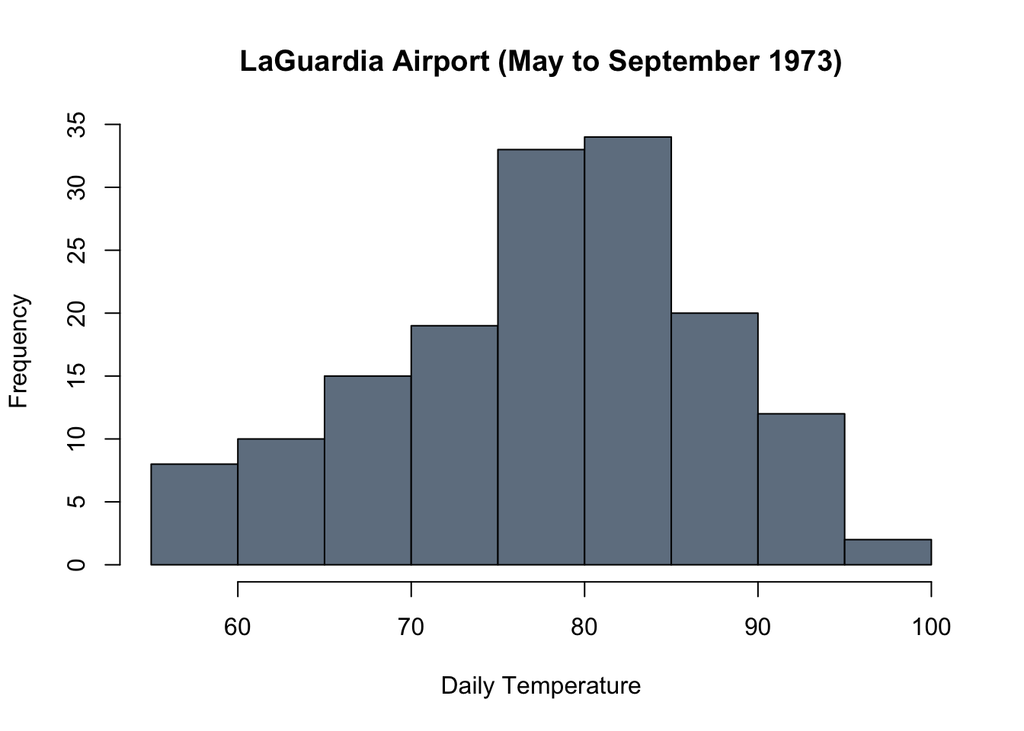

```r
# 3.5.1
hist(airquality$Temp, xlab="Daily Temperature", main="LaGuardia Airport (May to September 1973)", col="slategray")
```

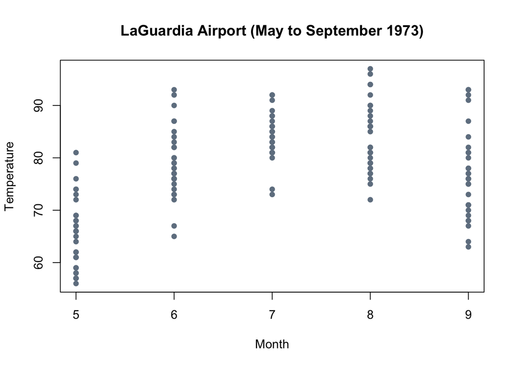

```r
# 3.5.2
plot(Temp ~ Month, data=airquality, xlab="Month", ylab="Temperature", main="LaGuardia Airport (May to September 1973)", pch=16, col="slategray")
```

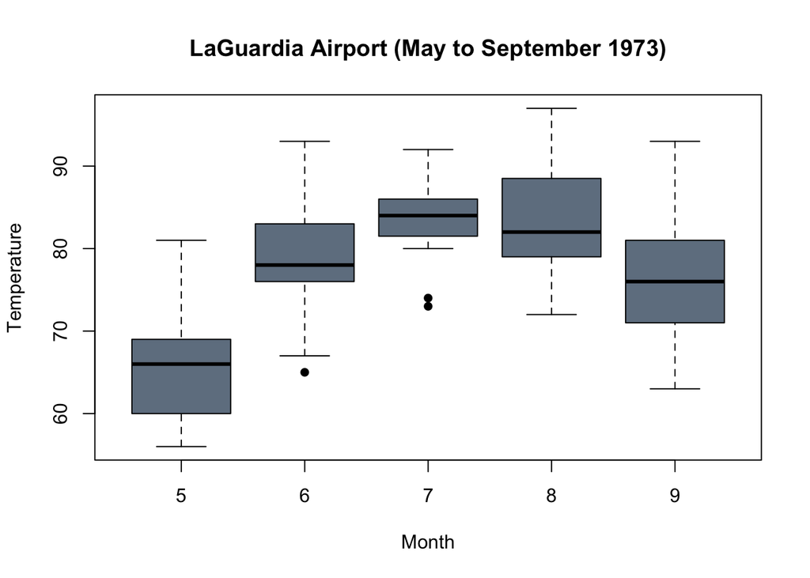

```r
# 3.5.3
boxplot(Temp ~ Month, data=airquality, xlab="Month", ylab="Temperature", main="LaGuardia Airport (May to September 1973)", pch=16, col="slategray")
```

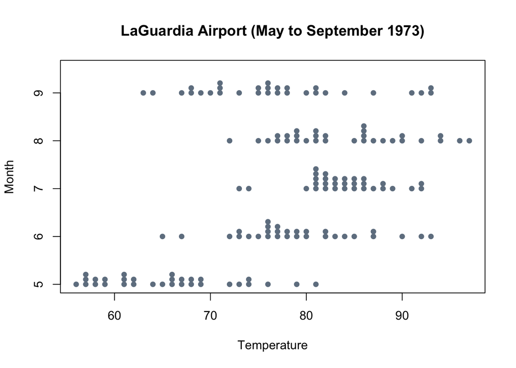

```r
# 3.5.4
stripchart(Temp ~ Month, data=airquality, ylab="Month", xlab="Temperature", main="LaGuardia Airport (May to September 1973)", pch=16, col="slategray", method="stack")
```

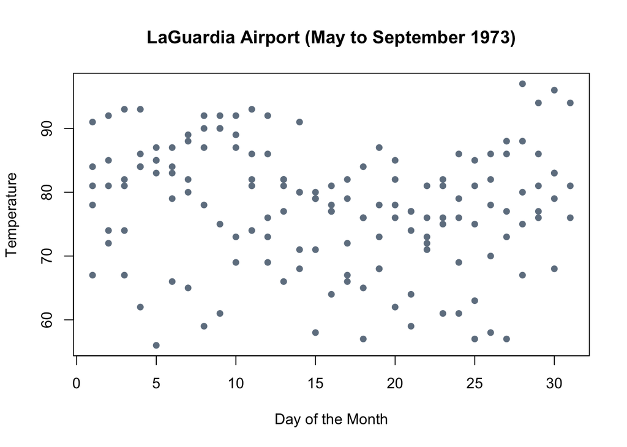

```r
# 3.5.5
plot(Temp ~ Day, data=airquality, xlab="Day of the Month", ylab="Temperature", main="LaGuardia Airport (May to September 1973)", pch=16, col="slategray")
```

###### Actually Usefull

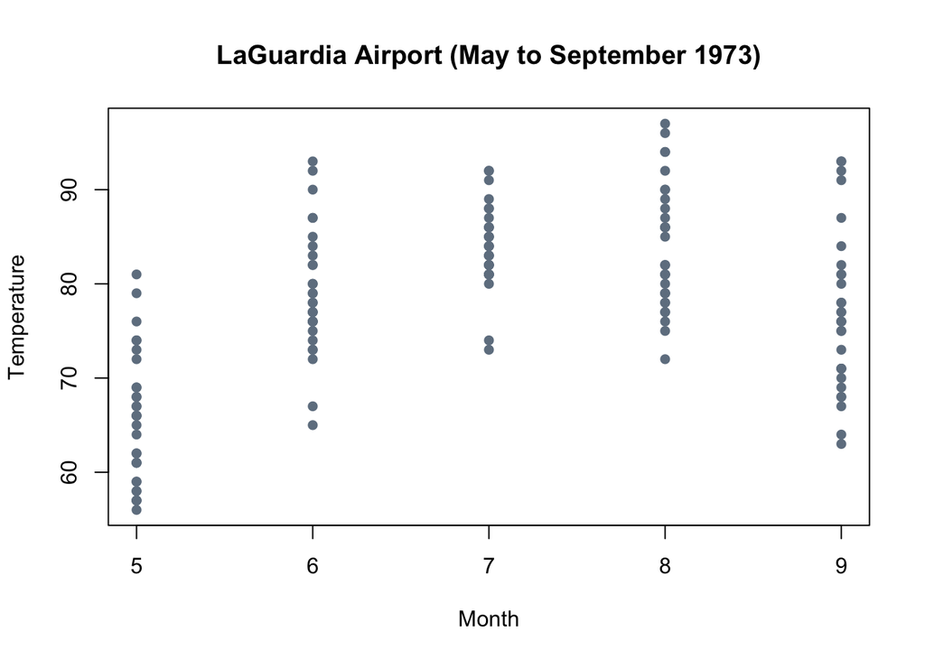

```r
# 3.5.2
plot(Temp ~ Month, data=airquality, xlab="Month", ylab="Temperature", main="LaGuardia Airport (May to September 1973)", pch=16, col="slategray")
```

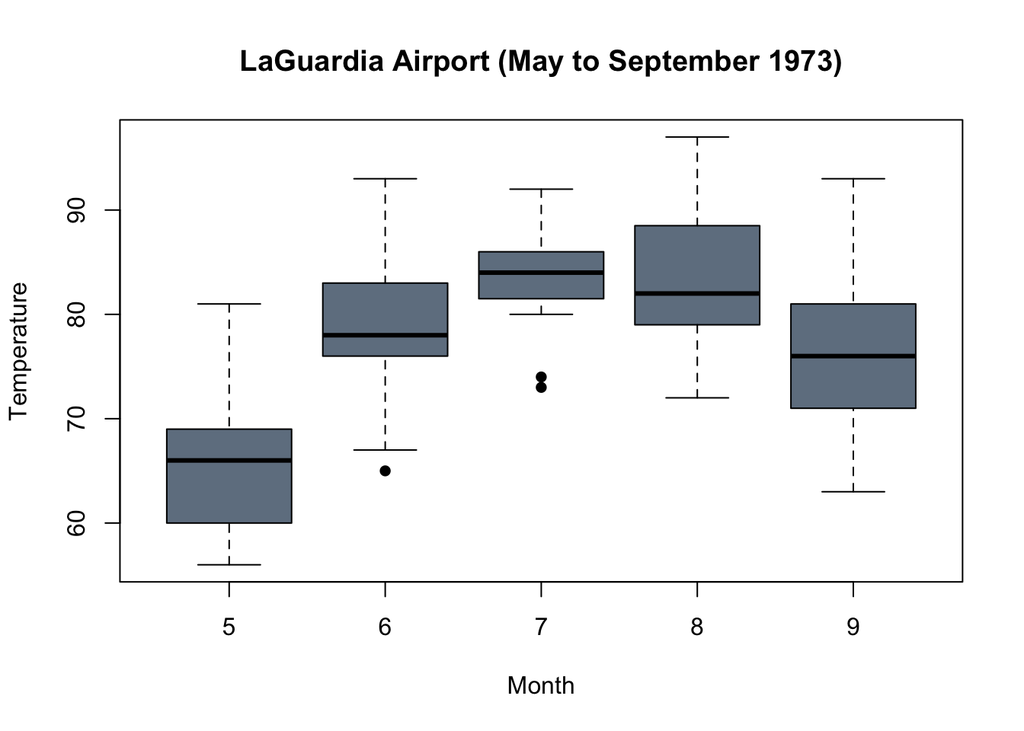

```r
# 3.5.3
boxplot(Temp ~ Month, data=airquality, xlab="Month", ylab="Temperature", main="LaGuardia Airport (May to September 1973)", pch=16, col="slategray")
```

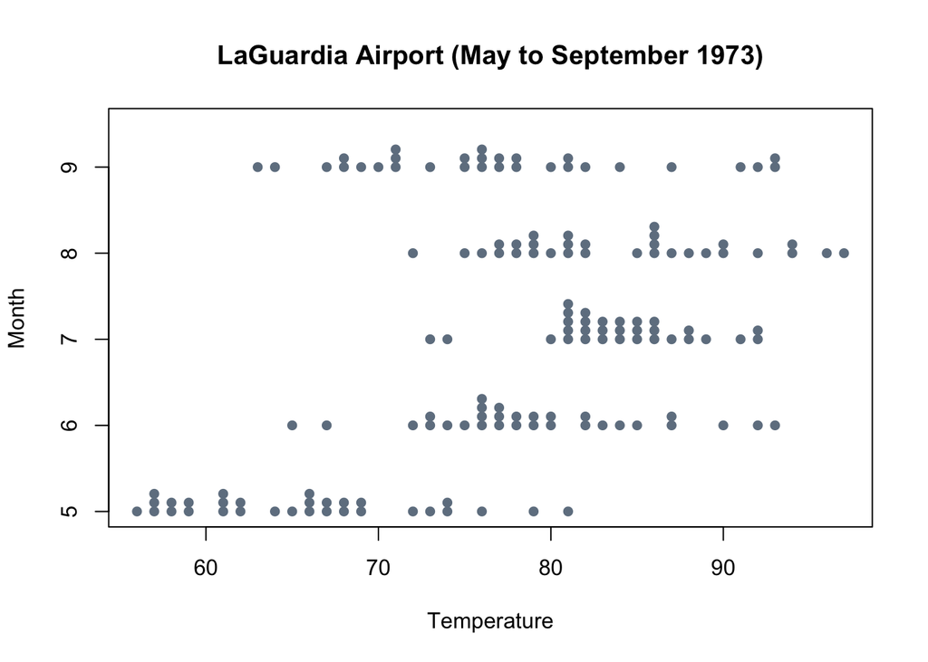

```r
# 3.5.4
stripchart(Temp ~ Month, data=airquality, ylab="Month", xlab="Temperature", main="LaGuardia Airport (May to September 1973)", pch=16, col="slategray", method="stack")
```

#### 3.6

In your R Console, type the commands:

> ?Orange  
> View(Orange)

```r
# f.
Orange %>%
  group_by(age) %>%
  summarise(
    "Age (days)" = first(age),
    "Trunk Circumference (mm)" = median(circumference, na.rm = TRUE)
  ) %>%
  ungroup() %>%
  select("Age (days)", "Trunk Circumference (mm)") %>%
  pander()
```

| Age (days) | Trunk Circumference (mm) |
| --- | --- |
| 118 | 30 |
| 484 | 58 |
| 664 | 87 |
| 1004 | 125 |
| 1231 | 142 |
| 1372 | 174 |
| 1582 | 177 |

#### 3.7

Select all of the following graphics that would be useful for displaying the above data.

Hint: Run the codes in R to see the graph they produce.

###### Potentially Usefull

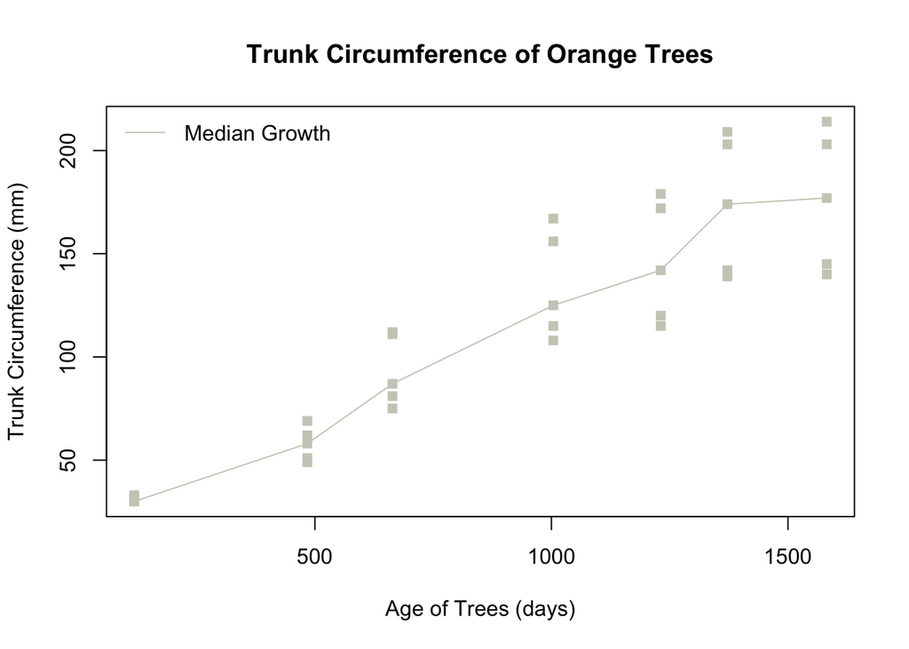

```r
# g1.
plot(circumference ~ age, data=Orange, ylab="Trunk Circumference (mm)", xlab="Age of Trees (days)", main="Trunk Circumference of Orange Trees", col="ivory3", pch=15)
Orange.m <- median(circumference ~ age, data=Orange)
lines(names(Orange.m), Orange.m, col="ivory3")
legend("topleft", legend="Median Growth", lty=1, col='ivory3', bty='n')
```

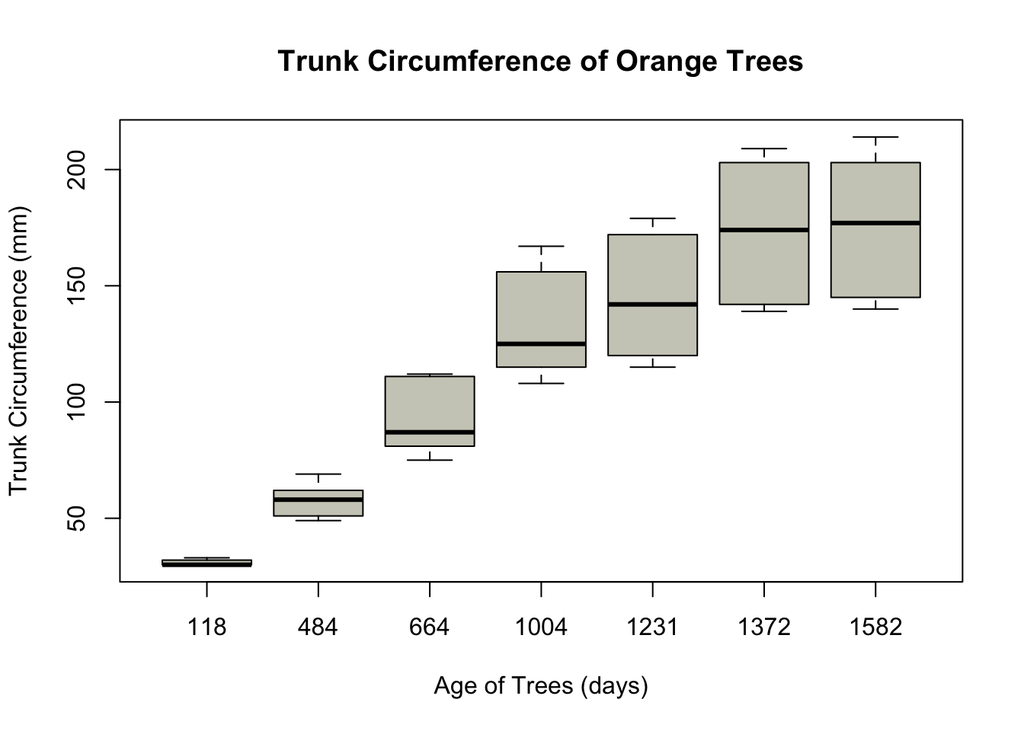

```r
# g2.
boxplot(circumference ~ age, data=Orange, ylab="Trunk Circumference (mm)", xlab="Age of Trees (days)", main="Trunk Circumference of Orange Trees", col="ivory3")
```

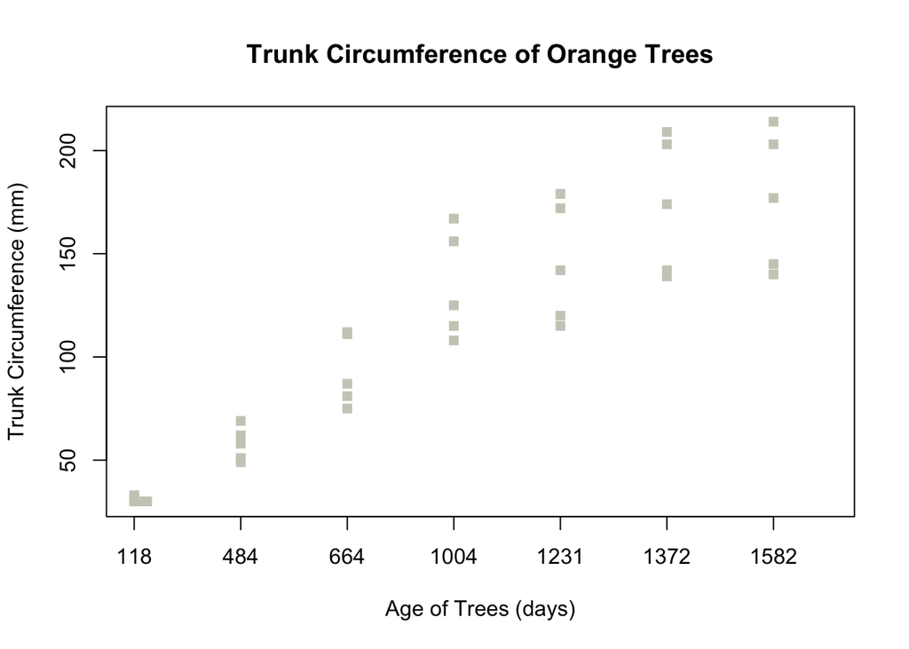

```r
# g3.
stripchart(circumference ~ age, data=Orange, ylab="Trunk Circumference (mm)", xlab="Age of Trees (days)", main="Trunk Circumference of Orange Trees", col="ivory3", pch=15, method="stack", vertical=TRUE)
```

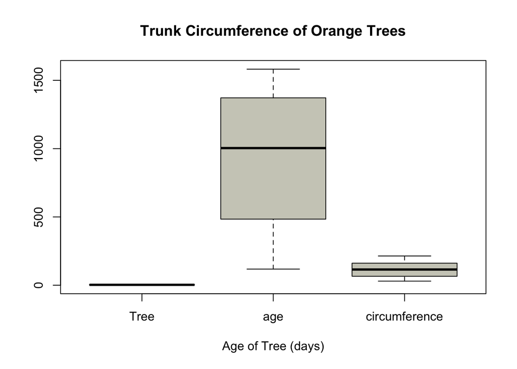

```r
# g4.
boxplot(Orange, xlab="Age of Tree (days)", main="Trunk Circumference of Orange Trees", col="ivory3")
```

###### Actually Usefull

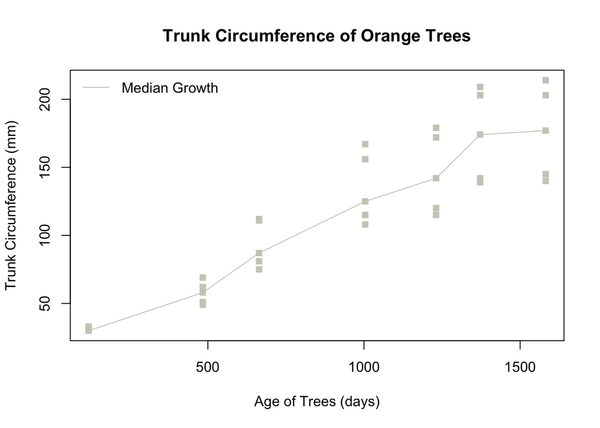

```r
# g1.
plot(circumference ~ age, data=Orange, ylab="Trunk Circumference (mm)", xlab="Age of Trees (days)", main="Trunk Circumference of Orange Trees", col="ivory3", pch=15)
Orange.m <- median(circumference ~ age, data=Orange)
lines(names(Orange.m), Orange.m, col="ivory3")
legend("topleft", legend="Median Growth", lty=1, col='ivory3', bty='n')
```

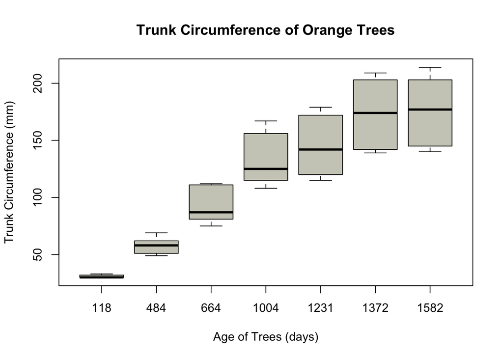

```r
# g2.
boxplot(circumference ~ age, data=Orange, ylab="Trunk Circumference (mm)", xlab="Age of Trees (days)", main="Trunk Circumference of Orange Trees", col="ivory3")
```

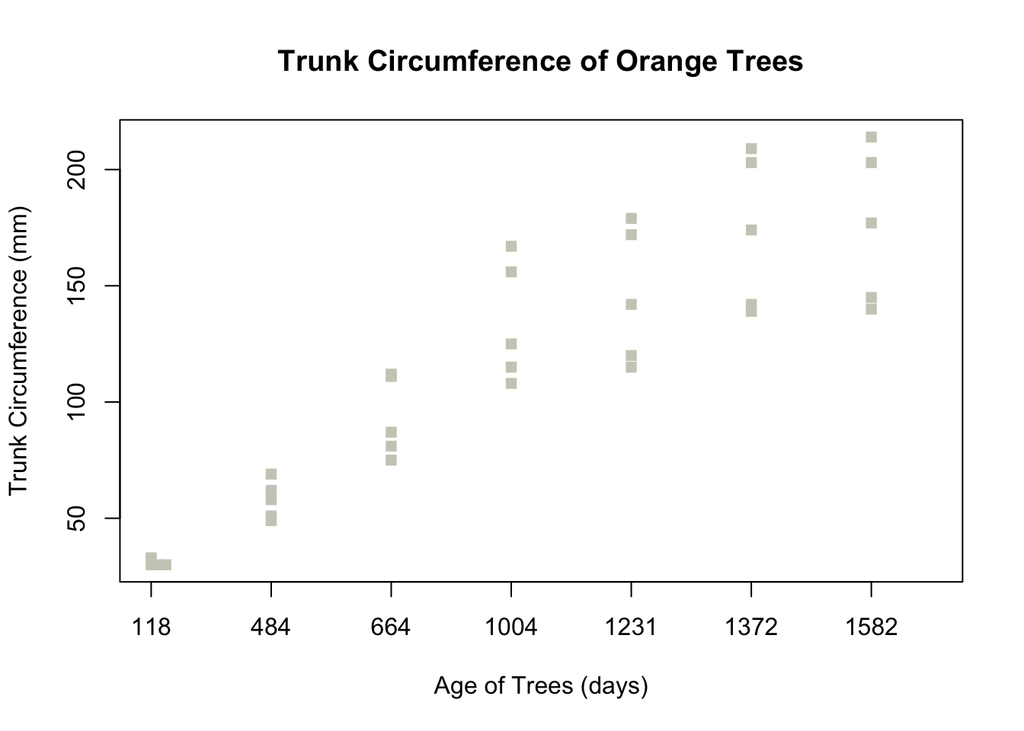

```r
# g3.
stripchart(circumference ~ age, data=Orange, ylab="Trunk Circumference (mm)", xlab="Age of Trees (days)", main="Trunk Circumference of Orange Trees", col="ivory3", pch=15, method="stack", vertical=TRUE)
```

#### 3.8

During which age interval did the most rapid overall median growth occur (in the circumference of the orange trees that were sampled)?

```r
# h. During which age interval did the most rapid overall median growth occur (in the circumference of the orange trees that were sampled)?
result <- Orange %>%
  group_by(age) %>%
  summarise(
    "Age (days)" = first(age),
    "Median Growth (mm)" = median(circumference, na.rm = TRUE)
  ) %>%
  ungroup() %>%
  arrange(`Age (days)`) %>%
  mutate(
    Previous_Age = lag(`Age (days)`),  # Store previous age before filtering
    Growth_Difference = `Median Growth (mm)` - lag(`Median Growth (mm)`)  # Compute growth before filtering
  )

# Identify the row with the maximum growth difference
max_growth_row <- result %>%
  slice_max(Growth_Difference, n = 1)  # Get the row with max difference

# Extract start and end ages from precomputed values
start_age <- max_growth_row$Previous_Age
end_age <- max_growth_row$`Age (days)`

cat(start_age, "and", end_age, "days\n")
```

```
## 664 and 1004 days
```

## Q4

#### 4.1

```r
# a.
airquality %>%
  group_by(Month) %>%
  mutate(
    `Month Number` = first(Month),  # Ensure single row per group
    `Month New` = first(paste0(Month, " (", month.abb[Month], ")")),  # Format month name
    `Mean Temp` = first(mean(Temp, na.rm = TRUE))  # Compute mean once per group
  ) %>%
  ungroup() %>%
  distinct(`Month New`, .keep_all = TRUE) %>%  # Keep only one row per group
  select(
    Month = `Month New`,  # Rename for final output
    `Mean Temperature at La Guardia Airport (degrees Fahrenheit)` = `Mean Temp`
  ) %>%
  arrange(`Month`) %>%  # Arrange correctly
  pander()
```

| Month | Mean Temperature at La Guardia Airport (degrees Fahrenheit) |
| --- | --- |
| 5 (May) | 65.55 |
| 6 (Jun) | 79.1 |
| 7 (Jul) | 83.9 |
| 8 (Aug) | 83.97 |
| 9 (Sep) | 76.9 |

## Q5

#### Introduction

Consider the Riders dataset in R. (You may need to load library(mosaicData).)

#### 5.1

How many total riders were observed on each day of the week? (Hint: the sum() function works the same way as mean()…)

```r
# a.
Riders %>%
  group_by(day) %>%
  summarise(
    `Day of the Week` = first(day),
    `Total Number of Riders Observed` = sum(riders)
  ) %>%
  ungroup() %>%
  distinct(`Day of the Week`, .keep_all = TRUE) %>%
    mutate(
    `Day of the Week` = factor(
      paste0(`Day of the Week`, "s"),  # Append "s" to each day
      levels = paste0(c("Monday", "Tuesday", "Wednesday", "Thursday", "Friday", "Saturday", "Sunday"), "s")  # Maintain correct order
    )
  ) %>%
  arrange(`Day of the Week`) %>%  # Ensure sorting respects new order
  select(
    `Day of the Week`,
    `Total Number of Riders Observed`
  ) %>%
  pander()
```

| Day of the Week | Total Number of Riders Observed |
| --- | --- |
| Mondays | 4698 |
| Tuesdays | 4423 |
| Wednesdays | 4012 |
| Thursdays | 5593 |
| Fridays | 5269 |
| Saturdays | 4623 |
| Sundays | 5168 |

## Q6

#### Introduction

Use the mtcars dataset in R to answer these questions.

#### 6.1

Which of the following properly describes the mtcars data set?

```r
# a.
cat("It contains data from the 1974 Motor Trend US magazine.")
```

```
## It contains data from the 1974 Motor Trend US magazine.
```

#### 6.2

How many variables are in the mtcars data set?

```r
# b.
var_count <- ncol(mtcars)  # Count number of columns
cat("Variables: ", var_count)
```

```
## Variables:  11
```

#### 6.3

How many observations are in the mtcars data set? (Hint: try View(…))

```r
# c.
record_count <- nrow(mtcars)  # Count number of columns
cat("Records: ", record_count)
```

```
## Records:  32
```

#### 6.4

How many vehicles are represented in the dataset for 4, 6, and 8 cylinder vehicles? (Hint: use the table(…) function.)

```r
# d.
mtcars %>%
  filter(cyl %in% c(4, 6, 8)) %>%
  group_by(cyl) %>%  # Group by cylinder type
  summarise(
    `Cylinders` = first(cyl),  # Keep only one row per group
    `Number of Vehicles in the Dataset` = n()  # Count vehicles per cylinder group
  ) %>%
  ungroup() %>%
  select(`Cylinders`, `Number of Vehicles in the Dataset`) %>%
  pander()
```

| Cylinders | Number of Vehicles in the Dataset |
| --- | --- |
| 4 | 11 |
| 6 | 7 |
| 8 | 14 |

#### 6.5

According to the mtcars data, on average, vehicles with 4 cylinders get the best (highest) gas mileage. What is the average mpg for automatic and manual transmission vehicles with 4 cylinders? (Round answers to the nearest tenth.)

```r
# e.
mtcars %>%
  filter(cyl == 4) %>%
  group_by(am) %>%
  summarise(
    `Transmission` = first(ifelse(am== 0, "Automatic", "Manual")),
    `Mean Gas Mileage for 4 Cylinder mtcars Vehicles (mpg)` = first(mean(mpg, na.rm = TRUE))
  ) %>%
  ungroup() %>%
  select(`Transmission`, `Mean Gas Mileage for 4 Cylinder mtcars Vehicles (mpg)`) %>%
  pander()
```

| Transmission | Mean Gas Mileage for 4 Cylinder mtcars Vehicles (mpg) |
| --- | --- |
| Automatic | 22.9 |
| Manual | 28.07 |

#### 6.6

According to the mtcars data, on average, vehicles with 8 cylinders have the best (fastest) quarter mile time. What is the mean quarter mile time (qsec) for automatic and manual transmission vehicles with 8 cylinders? (Round answers to nearest tenth.)

```r
# f.
mtcars %>%
  filter(cyl == 8) %>%
  group_by(am) %>%
  summarise(
    `Transmission` = first(ifelse(am== 0, "Automatic", "Manual")),
    `Mean Quarter Mile Time for 8 Cylinder mtcars Vehicles (sec)` = first(mean(qsec, na.rm = TRUE))
  ) %>%
  ungroup() %>%
  select(`Transmission`, `Mean Quarter Mile Time for 8 Cylinder mtcars Vehicles (sec)`) %>%
  pander()
```

| Transmission | Mean Quarter Mile Time for 8 Cylinder mtcars Vehicles (sec) |
| --- | --- |
| Automatic | 17.14 |
| Manual | 14.55 |

#### 6.7

According to the mtcars data, how many thousands of pounds does the heaviest 6 cylinder car with an automatic transmission weigh? (Round to the nearest tenth.)

```r
# g.
auto_lbs <- mtcars %>%
  filter(cyl == 6, am == 0) %>%
  pull(wt) %>%
  max(na.rm = TRUE)

round_auto_lbs <- round(auto_lbs, 1)

cat(round_auto_lbs, "k lbs")
```

```
## 3.5 k lbs
```

#### 6.8

How many more thousands of pounds does it weigh than the heaviest 6 cylinder car with a manual transmission? (Round to the nearest tenth.)

```r
# h.
manual_lbs <- mtcars %>%
  filter(cyl == 6, am == 1) %>%
  pull(wt) %>%
  max(na.rm = TRUE)

diff <- auto_lbs - manual_lbs
round_manual_lbs <- round(diff, 1)

cat(round_manual_lbs, "k lbs")
```

```
## 0.6 k lbs
```